# td3_aymericNoel.R

Aymeric-PC

Fri Oct 04 14:32:13 2019

# TP 3 Aymeric Noel

# question 1

```r
setwd("C:/Users/Aymeric-PC/Desktop/Cours/machine learning")
library(readr)
Social_Network_Ads <- read_csv("Social_Network_Ads.csv")
```

## *question 2*

```r
summary(Social_Network_Ads)
```

```
##     User ID            Gender               Age        EstimatedSalary
##  Min.   :15566689   Length:400         Min.   :18.00   Min.   : 15000
##  1st Qu.:15626764   Class :character   1st Qu.:29.75   1st Qu.: 43000
##  Median :15694342   Mode  :character   Median :37.00   Median : 70000
##  Mean   :15691540                      Mean   :37.66   Mean   : 69743
##  3rd Qu.:15750363                      3rd Qu.:46.00   3rd Qu.: 88000
##  Max.   :15815236                      Max.   :60.00   Max.   :150000
##    Purchased
##  Min.   :0.0000
##  1st Qu.:0.0000
##  Median :0.0000
##  Mean   :0.3575
##  3rd Qu.:1.0000
##  Max.   :1.0000
```

We can see that social_network_ads has 5 variables : user ID, Gender,Age, Estimated salary and purchased

```r
correlation<-cor(Social_Network_Ads$Age,Social_Network_Ads$EstimatedSalary)
correlation
```

```
## [1] 0.155238
```

There is a very small correlation between the age and the estimated salary

```r
correlation<-cor(Social_Network_Ads$Purchased ,Social_Network_Ads$EstimatedSalary)
correlation
```

```
## [1] 0.362083
```

There is a medium correlation between the purchased and the estimatedSalary

```r
correlation<-cor(Social_Network_Ads$Purchased ,Social_Network_Ads$Age)
correlation
```

```
## [1] 0.6224542
```

There is a string relation between the age and the purchased, this is the strongest correlation

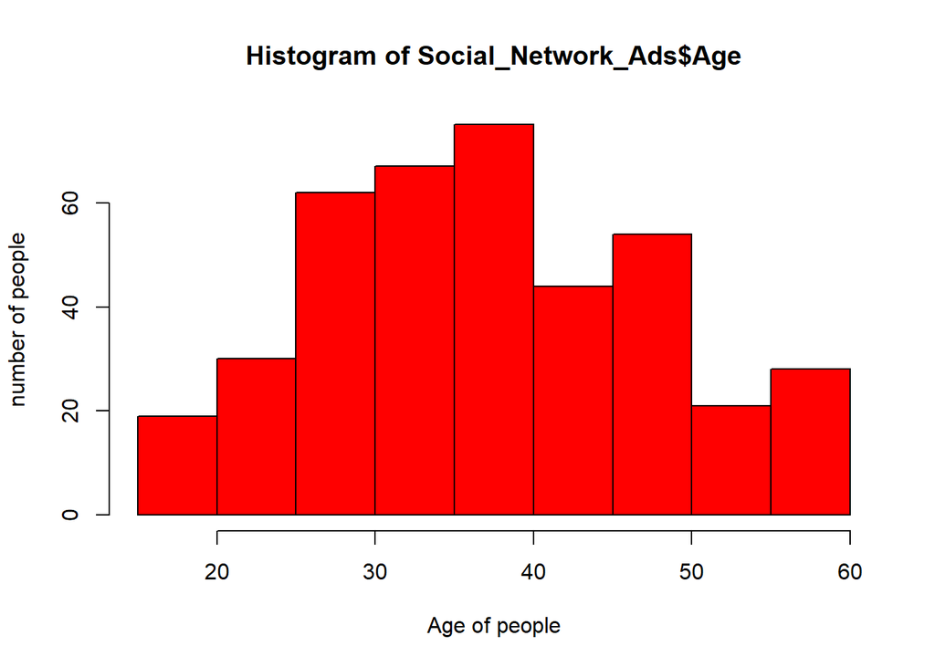

```r
hist(Social_Network_Ads$Age,xlab = "Age of people",ylab = "number of people",col="red")
```

We can see that there is more people who are between 25 and 40 years

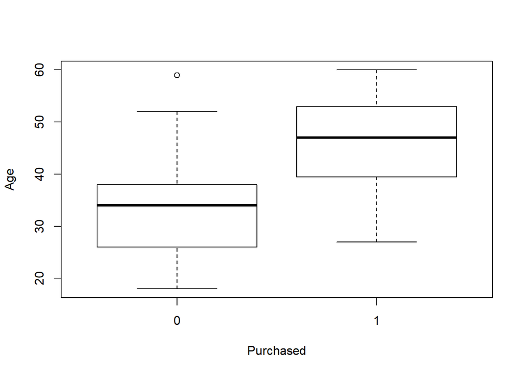

```r
boxplot(Social_Network_Ads$Age~Social_Network_Ads$Purchased,xlab="Purchased",ylab="Age")
```

This boxplot confirm that there are more purchase when the person is older

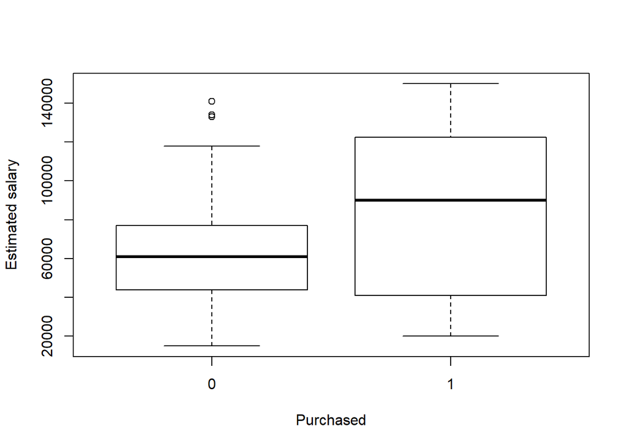

```r
boxplot(Social_Network_Ads$EstimatedSalary~Social_Network_Ads$Purchased,xlab="Purchased",ylab="Estimated salary")
```

There is more purchase when the median salary is higher than those who dont buy ##*question 3*

```r
Social_Network_Ads$Age=scale(Social_Network_Ads$Age)[,1]
Social_Network_Ads$EstimatedSalary=scale(Social_Network_Ads$EstimatedSalary)[,1]
library(caTools)
set.seed(123)

split = sample.split(Social_Network_Ads$Purchased, SplitRatio = 0.75)
training_set = subset(Social_Network_Ads, split == TRUE)
test_set = subset(Social_Network_Ads, split == FALSE)
```

## *question 4*

estimatedSalary_scale_training<- scale(training_set$EstimatedSalary)[,1]

estimatedSalary_scale_test<- scale(test_set$EstimatedSalary)[,1]

age_scale_training<- scale(training_set$Age)[,1]

age_scale_test<- scale(test_set$Age)[,1]

## *question 5*

```r
model<- glm(Purchased~Age,family = "binomial",data=training_set)
```

## *question 6*

We must pass the argument family=binomial in order to tell to run a logistic regression rather than some other type of generalized linear model.

## *question 7*

```r
summary(model)
```

```
##
## Call:
## glm(formula = Purchased ~ Age, family = "binomial", data = training_set)
##
## Deviance Residuals:
##     Min       1Q   Median       3Q      Max
## -2.5341  -0.6641  -0.2950   0.5437   2.4392
##
## Coefficients:
##             Estimate Std. Error z value Pr(>|z|)
## (Intercept)  -0.8940     0.1658  -5.392 6.96e-08 ***
## Age           1.9958     0.2347   8.502  < 2e-16 ***
## ---
## Signif. codes:  0 '***' 0.001 '**' 0.01 '*' 0.05 '.' 0.1 ' ' 1
##
## (Dispersion parameter for binomial family taken to be 1)
##
##     Null deviance: 390.89  on 299  degrees of freedom
## Residual deviance: 252.11  on 298  degrees of freedom
## AIC: 256.11
##
## Number of Fisher Scoring iterations: 5
```

```r
coef(model)
```

```
## (Intercept)         Age
##  -0.8940039   1.9958049
```

## *question 8*

Age is significant because there is p value is near 0, p value < 2e-16 ##*question 9*

```r
AIC(model)
```

```
## [1] 256.109
```

The value of AIC is 256.109

## *question 10*

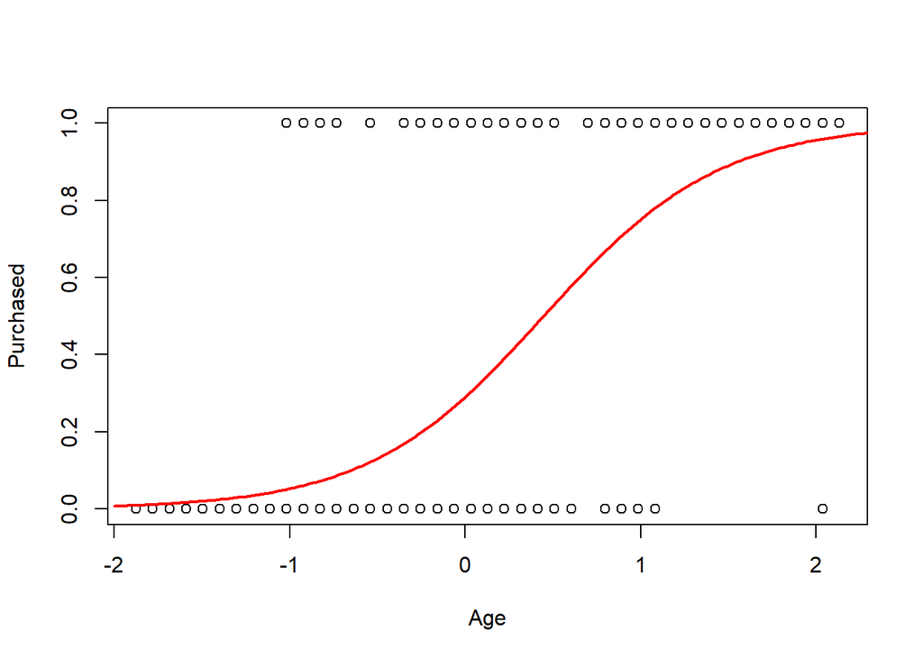

```r
plot(training_set$Age,training_set$Purchased,xlab = "Age",ylab = "Purchased")

x <- seq(-2, 3, l = 200)
y <- exp(-(model$coefficients[1] + model$coefficients[2] * x))
y <- 1 / (1 + y)
lines(x, y, col = 2, lwd = 2)

library(ggplot2)
```

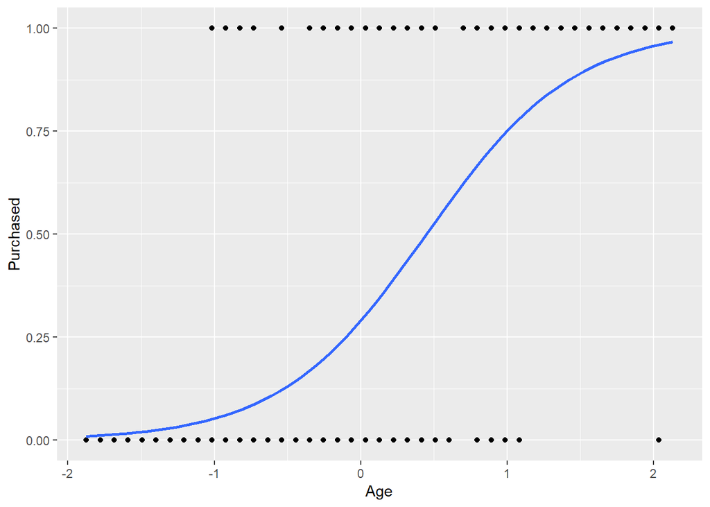

```r
ggplot(training_set, aes(x=Age, y=Purchased)) +
  geom_point() +
  stat_smooth(method="glm", method.args=list(family="binomial"), se=FALSE)
```

## *question 11*

```r
model2<-glm(Purchased~Age+EstimatedSalary,family = binomial,data = training_set)
```

## *question 12*

```r
summary(model2)
```

```
##
## Call:
## glm(formula = Purchased ~ Age + EstimatedSalary, family = binomial,
##     data = training_set)
##
## Deviance Residuals:
##     Min       1Q   Median       3Q      Max
## -3.0753  -0.5235  -0.1161   0.3224   2.3977
##
## Coefficients:
##                 Estimate Std. Error z value Pr(>|z|)
## (Intercept)      -1.1799     0.2007  -5.878 4.16e-09 ***
## Age               2.6383     0.3469   7.606 2.83e-14 ***
## EstimatedSalary   1.3572     0.2264   5.996 2.03e-09 ***
## ---
## Signif. codes:  0 '***' 0.001 '**' 0.01 '*' 0.05 '.' 0.1 ' ' 1
##
## (Dispersion parameter for binomial family taken to be 1)
##
##     Null deviance: 390.89  on 299  degrees of freedom
## Residual deviance: 199.78  on 297  degrees of freedom
## AIC: 205.78
##
## Number of Fisher Scoring iterations: 6
```

The variables are significants because p value are nears 0. Both p value (for age and estimatedSalary)

## *question 13*

```r
AIC(model2)
```

```
## [1] 205.7819
```

AIC(model2)=205.7819 < AIC(model)=256.109 so this is a better model

## *question 14*

```r
predictions=predict(model2,newdata =test_set,type="response")
```

## *question 15*

```r
for (i in 1:100)
{
  if(predictions[i]>0.5)
    {predictions[i]=1}
  else
    {predictions[i]=0}
}
```

## *question 16*

```r
matrix<-table(predictions,test_set$Purchased)
matrix
```

```
##
## predictions  0  1
##           0 57 10
##           1  7 26
```

So we have 83 good predictions on 100 values

## *question 17*

```r
AnalyseMatrix<-function(x){
  accuracy <-(x[1,1]+x[2,2])/sum(x)
  cat("accuracy : ")
  print(accuracy)
  precision<-x[1,1]/(x[1,1]+x[2,1])
  cat("precision : ")
  print(precision)
  sensitivity<- x[1,1]/(x[1,1]+x[1,2])
  cat("sensitivity :")
  print(sensitivity)
  specificity<-x[2,2]/(x[2,2]+x[1,2])
  cat("specifity : ")
  print(specificity)
}
AnalyseMatrix(matrix)
```

```
## accuracy : [1] 0.83
## precision : [1] 0.890625
## sensitivity :[1] 0.8507463
## specifity : [1] 0.7222222
```

## *question 18*

```r
library("ROCR")
```